# Oldtown Neighborhood: Real Estate Overview

Mia Murphy

2023-10-23

# Introduction

This report provides a visual exploration of real estate properties in the “Oldtown” neighborhood, with a particular focus on understanding the characteristics and pricing of historical properties. Our goal is to offer stakeholders a clear and concise overview, aiding in decision-making and investment strategies.

## Oldtown at a Glance

“Oldtown” is a neighborhood with a rich history, reflected in its diverse range of properties. This report delves into the unique aspects of the real estate market in “Oldtown,” highlighting the trends and patterns that define this area.

## Sale Price Distribution

The distribution of sale prices gives us a snapshot of the affordability and variety of properties available.

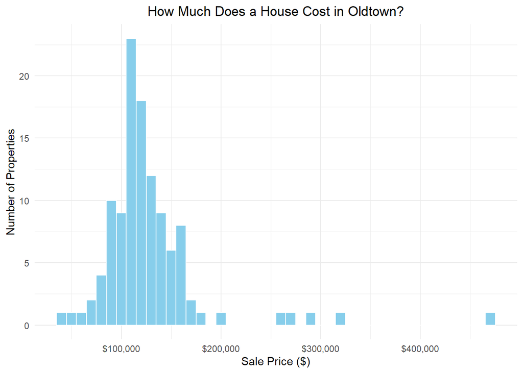

The histogram above illustrates the range of property prices in “Oldtown.” Most properties fall within the `$100,000 to $150,000` range, showcasing the neighborhood’s affordability.

## Historical vs. Non-Historical Properties

“Oldtown” is home to many historical properties. We define historical properties as those built before 1930. Let’s see how they compare to more modern homes in terms of price and quality.

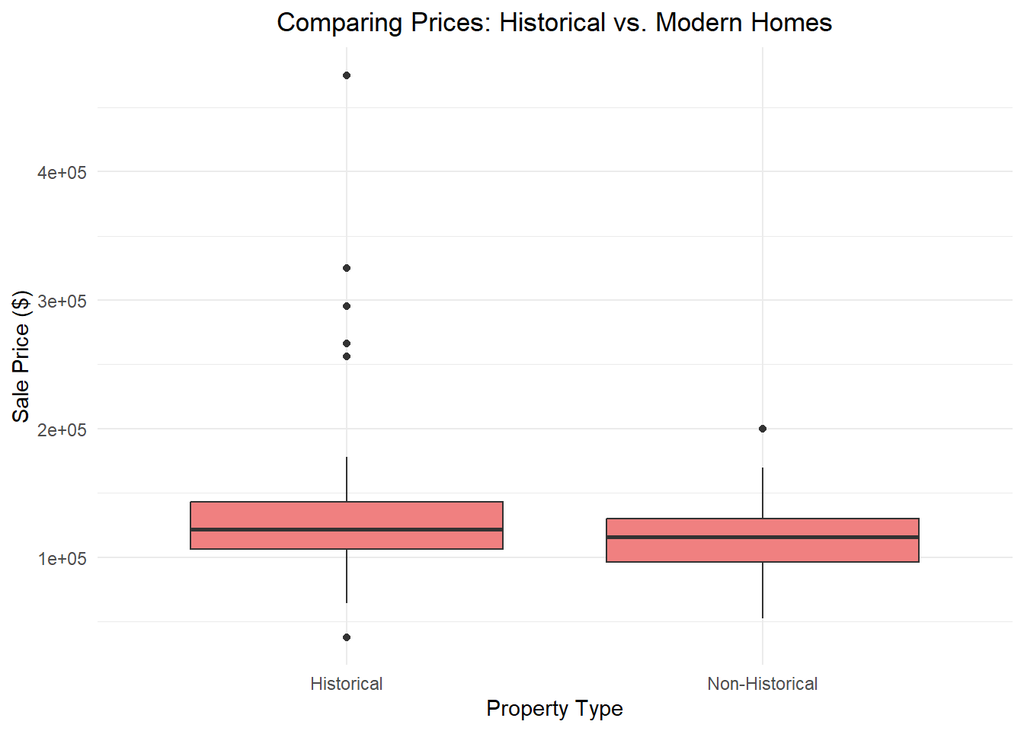

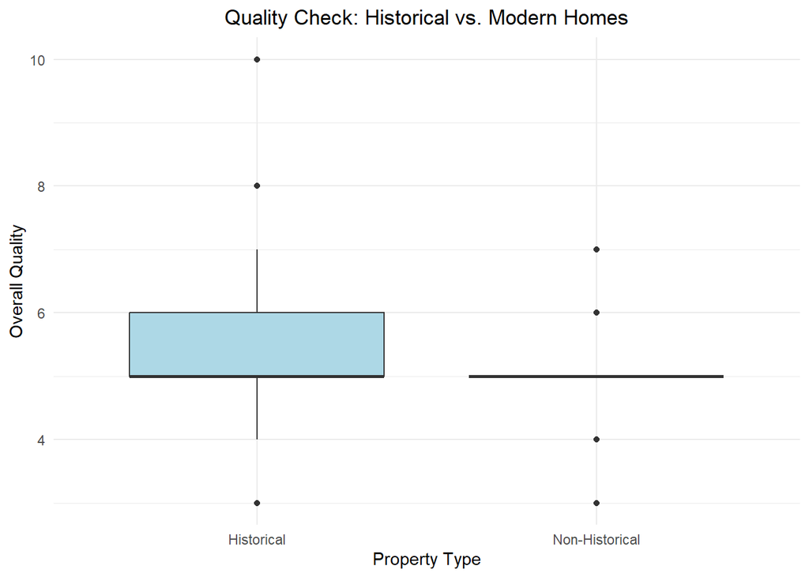

In the first chart, we compare the sale prices of historical and modern homes. Historical homes tend to be priced higher, showcasing their market value despite their age. The second chart compares the overall quality ratings, and we can see that both historical and modern homes have similar quality distributions.

## Living Space and Sale Price

The size of a home, measured in living area square footage, often plays a crucial role in determining its price. Let’s see how this holds up in “Oldtown,” particularly for historical homes.

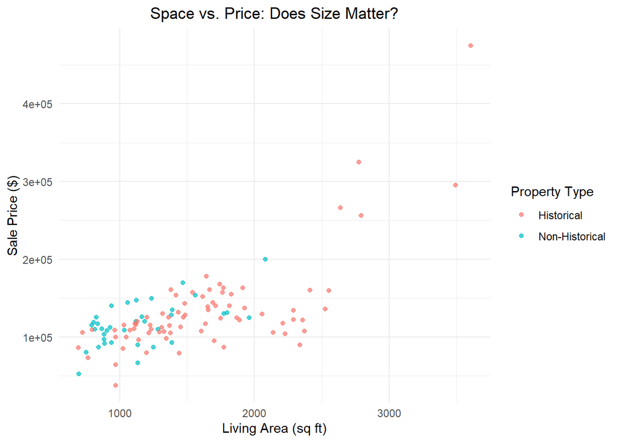

# Conclusion

“Oldtown” presents a unique real estate landscape, blending historical charm with modern living. Historical homes in this neighborhood command higher prices, potentially due to their larger living spaces and the intrinsic value of historical properties. This analysis provides stakeholders with a clear visual understanding of “Oldtown’s” real estate market, aiding in informed decision-making and investment strategies.